# A Tutorial for the `Sandwich` R Package

Yue Lin, Chengdong Xu, Jinfeng Wang

2021-08-27

The `Sandwich` package implements the Sandwich model-based mapping[^1] based on the spatial stratified heterogeneity (SSH) theory[^2]. It consists of sampling, SSH, and reporting layers. The goal of this model is to estimate the mean value of the sampling attribute and its standard error for each reporting unit leveraging the known distribution of the population in the SSH layer. Since the Sandwich model does not rely on the spatial dependence of the population, when the spatial dependence is weak, Sandwich is still applicable as long as one properly stratifies the geospatial surface. Figure 1 is an overview of the Sandwich model structure.

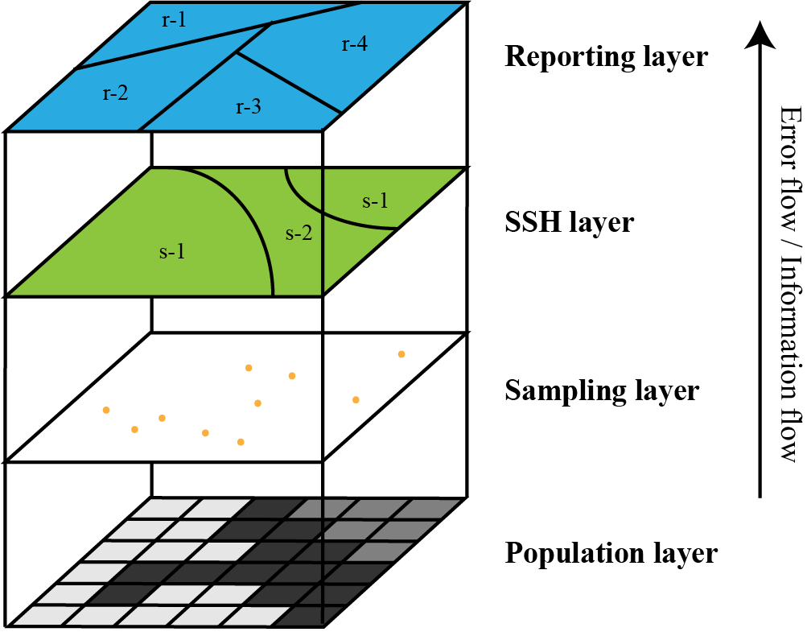

Figure 1. Structure of the Sandwich model.

To use the `Sandwich` package, first install it from source code (only do this once).

```r
# Install Sandwich package
# require("devtools")
# devtools::install_github("linyuehzzz/sandwich_spatial_interpolator",
#                          subdir="r/Sandwich", build_vignettes = TRUE)
```

Then load the installed package into your environment using `library()`. Make sure to capitalize the first letter of **S**andwich. Remember to load the package every time you use it.

```r
# Import Sandwich package
library("Sandwich")
```

Here,we present two case studies to demonstrate the functionality of this package.

## Human population in Heshun County, China

The first case study interpolates the human population density in Heshun County, China based on a sample of 167 units. A zonation consists of 5 spatially contiguous strata is used as a candidate SSH layer. The administrative division of 10 townships in Heshun County is used as the reporting layer. The sampling, SSH, and reporting layers are all in the shapefile format.

### Loading data

```r
# Input data from shapefiles
hs.sampling.name <- system.file("data/hs.sampling.shapefile.shp",
                                package="Sandwich")
hs.ssh.name <- system.file("data/hs.ssh.shapefile.shp",
                           package="Sandwich")
hs.reporting.name <- system.file("data/hs.reporting.shapefile.shp",
                                 package="Sandwich")

hs.data <- load.data.shp(sampling.file=hs.sampling.name,
                      ssh.file=hs.ssh.name,
                      reporting.file=hs.reporting.name)
```

### Selection of the SSH layer(s)

The accuracy of the Sandwich model is determined by the SSH layer. For an ideal SSH layer, values of the target attribute are expected to be homogeneous within each stratum and differ between the strata. To determine a proper SSH layer for the Sandwich model, the geographical detector model[^3] is applied to quantify the SSH of the target attribute with regard to the candidate stratification(s).

For the purpose of demonstration, we input `hs.ssh2.shapefile` as another candidate SSH layer.

```r
# Input another candidate SSH layer for demonstration
hs.ssh2.name <- system.file("data/hs.ssh2.shapefile.shp",
                            package="Sandwich")
hs.ssh2 <- read_sf(dsn=dirname(hs.ssh2.name),
                    layer=file_path_sans_ext(basename(hs.ssh2.name)))
```

First, we combine the sampling and the candidate SSH layers to a single data frame.

```r
# Prepare the SSH layer(s) for evaluation
hs.join <- ssh.data.shp(object=hs.data[[1]], ssh.lyr=hs.data[[2]], ssh.id="STR_1")
hs.join <- ssh.data.shp(object=hs.join, ssh.lyr=hs.ssh2, ssh.id="STR_2")
head(hs.join)
```

```
## Simple feature collection with 6 features and 6 fields
## Geometry type: POINT
## Dimension:     XYZ
## Bounding box:  xmin: 156491.4 ymin: 4126601 xmax: 171510.5 ymax: 4153214
## z_range:       zmin: 1320.701 zmax: 1500
## Projected CRS: WGS 84 / UTM zone 50N
## # A tibble: 6 x 7
##   CODE  Population     x     y                      geometry STR_1 STR_2
##   <chr>      <dbl> <dbl> <dbl>                   <POINT [m]> <chr> <chr>
## 1 02033         31  113.  37.5     Z (156491.4 4153214 1500) 05    11
## 2 01007         23  113.  37.2 Z (165240.2 4126601 1320.701) 05    02
## 3 01008         38  113.  37.2   Z (166538 4127516 1354.123) 05    02
## 4 01009         89  113.  37.3 Z (169540.8 4129381 1370.255) 05    02
## 5 01010         22  113.  37.3     Z (170685.2 4130558 1400) 05    02
## 6 01011        129  113.  37.3     Z (171510.5 4131899 1400) 05    02
```

```r
# Calculate the geographical detector q-statistic
ssh.test(object=hs.join, y="Population", x=c("STR_1", "STR_2"), test="factor")
```

```
## [[1]]
##       q-statistic      p-value
## STR_1   0.5841001 3.386389e-10
##
## [[2]]
##       q-statistic      p-value
## STR_2   0.2540372 8.683782e-06
```

```r
# Calculate the interaction detector
ssh.test(object=hs.join, y="Population", x=c("STR_1", "STR_2"), test="interaction")
```

```
##      [,1]    [,2]    [,3]
## [1,] "STR_1" "STR_2" "0.620092311481712"
## [2,] "STR_1" "STR_1" "0.58410012034806"
## [3,] "STR_2" "STR_2" "0.254037208669126"
```

### Running the Sandwich model

The Sandwich model-based mapping is performed using the `sandwich.model` function, which outputs the mean value of the sampling attribute and its standard error for each reporting unit.

```r
# Perform the SSH based spatial interpolation
hs.sw <- sandwich.model(object=hs.data, sampling.attr="Population", type="shp")
head(hs.sw)
```

```
## Simple feature collection with 6 features and 5 fields
## Geometry type: POLYGON
## Dimension:     XY
## Bounding box:  xmin: 151114.4 ymin: 4123480 xmax: 214095.3 ymax: 4165211
## Projected CRS: WGS 84 / UTM zone 50N
## # A tibble: 6 x 6
##   CODE   Area                                         geometry  mean    se    df
##   <chr> <dbl>                                    <POLYGON [m]> <dbl> <dbl> <dbl>
## 1 02    427.  ((153690.1 4149820, 153647.4 4149999, 153508.5 ~  211.  5.28    91
## 2 06    143.  ((191225.5 4151326, 191387.6 4151395, 191542.2 ~  287.  1.28    18
## 3 03    373.  ((178892 4151731, 179098.2 4151712, 179205.5 41~  304.  1.21    90
## 4 05    252.  ((172768 4143250, 172542.9 4143207, 172248.9 41~  178.  6.80    91
## 5 10     73.7 ((207615.6 4147664, 207785.4 4147473, 207928.5 ~  225.  1.94    40
## 6 01    186.  ((172768 4143250, 173154.8 4143172, 173615.2 41~  207.  5.46    91
```

The Sandwich estimates and the standard error can be visualized using `plot.mean` and `plot.se()`.

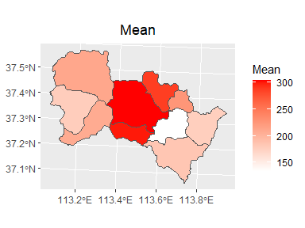

```r
# Plot the mean values of the interpolation estimates
plot.mean(object=hs.sw)
```

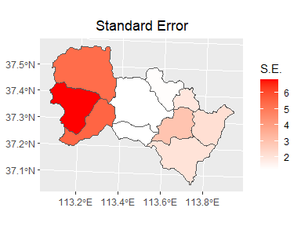

```r
# Plot the standard errors of the interpolation estimates
plot.se(object=hs.sw)
```

The confidence interval for the population mean in each reporting unit is computed using the `sandwich.ci` function. Here, we show an example of constructing a 95% confidence interval.

```r
# Calculate the confidence intervals of the interpolation estimates
hs.sw.ci <- sandwich.ci(object=hs.sw, level=.95)
head(hs.sw.ci)
```

```
## Simple feature collection with 6 features and 7 fields
## Geometry type: POLYGON
## Dimension:     XY
## Bounding box:  xmin: 151114.4 ymin: 4123480 xmax: 214095.3 ymax: 4165211
## Projected CRS: WGS 84 / UTM zone 50N
## # A tibble: 6 x 8
##   CODE   Area                            geometry  mean    se    df ci.low ci.up
##   <chr> <dbl>                       <POLYGON [m]> <dbl> <dbl> <dbl>  <dbl> <dbl>
## 1 02    427.  ((153690.1 4149820, 153647.4 41499~  211.  5.28    91   201.  222.
## 2 06    143.  ((191225.5 4151326, 191387.6 41513~  287.  1.28    18   284.  289.
## 3 03    373.  ((178892 4151731, 179098.2 4151712~  304.  1.21    90   301.  306.
## 4 05    252.  ((172768 4143250, 172542.9 4143207~  178.  6.80    91   165.  192.
## 5 10     73.7 ((207615.6 4147664, 207785.4 41474~  225.  1.94    40   221.  229.
## 6 01    186.  ((172768 4143250, 173154.8 4143172~  207.  5.46    91   196.  218.
```

The lower and upper bounds of the confidence interval can be visualized using the `plot.ci` function.

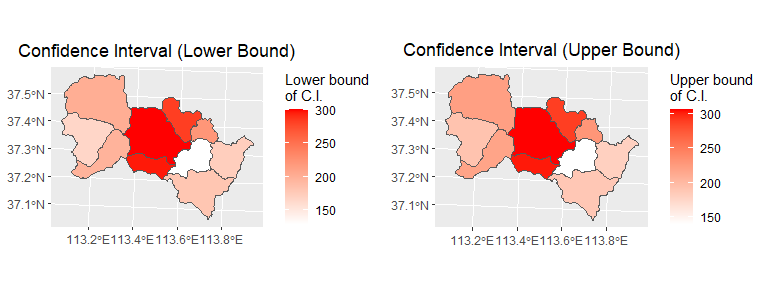

```r
# Plot the confidence intervals of the interpolation estimates
plot.ci(object=hs.sw.ci)
```

### Model validation

To evaluate the overall accuracy of the Sandwich model, a *k*-fold cross validation can be performed using the `sandwich.cv` function. A diagnostic statistic called root mean square error (RMSE) will be calculated. Here, we present the result of a 5-fold cross validation.

```r
# Perform k-fold cross validation
hs.cv <- sandwich.cv(object=hs.data, sampling.attr="Population", k=5, type="shp")
hs.cv
```

```
## [1] 116.7436
```

## Breast cancer incidence in mainland China

The second case study interpolates the breast cancer incidence across mainland China based on 242 samples retrieved from the Chinese Cancer Registry Annual Report. The urban-rural classification (either urban or rural areas are typically not connected in space) is used as the SSH layer. County-level divisions are used as the reporting units. In this example, all the input data are in csv format.

### Loading data

The `load.data.txt` function is used to prepare text files into a list of data frames for model input. Two files are needed for this function: one linking sampling and SSH layers, and the other linking reporting and SSH layers. The general formats of these files are speficied below.

Sampling-SSH

| y | SSH | Reporting | … |
| --- | --- | --- | --- |
| y1 | 2 | 3 | … |
| y2 | 1 | 3 | … |
| … | … | … | … |

Reporting-SSH

| Reporting | W1 | W2 | … |
| --- | --- | --- | --- |
| 1 |  |  | … |
| 2 |  |  | … |
| … |  |  | … |

```r
# Input data from text files
bc.sampling_ssh.name <- system.file("data/bc_sampling_ssh.csv",
                                package="Sandwich")
bc.reporting_ssh.name <- system.file("data/bc_reporting_ssh.csv",
                                 package="Sandwich")

bc.data <- load.data.txt(sampling_ssh.file=bc.sampling_ssh.name,
                         reporting_ssh.file=bc.reporting_ssh.name)

# Sampling-SSH
head(bc.data[[1]])
```

```
##   GBCODE Incidence SSHID        X        Y
## 1 110100        42     1 115.9642 39.86494
## 2 120100        44     1 117.3913 39.01184
## 3 120225        26     2 117.4309 40.00251
## 4 130129         9     2 114.2797 37.61767
## 5 130181        36     1 115.2870 37.91756
## 6 130227        20     2 118.3576 40.23177
```

```r
# Reporting-SSH
head(bc.data[[2]])
```

```
##   GBCODE        W1        W2
## 1 110100 0.8736000 0.1264000
## 2 110112 0.6115000 0.3885000
## 3 110113 0.5378000 0.4622000
## 4 110221 0.5245597 0.4754403
## 5 110224 0.5245597 0.4754403
## 6 110226 0.5245597 0.4754403
```

### Selection of the SSH layer(s)

First, we use the `ssh.data.txt` function to convert the input data for evaluation.

```r
# Prepare the SSH layer for evaluation
bc.join <- ssh.data.txt(object=bc.data)
head(bc.join)
```

```
##   GBCODE Incidence SSHID        X        Y
## 1 110100        42     1 115.9642 39.86494
## 2 120100        44     1 117.3913 39.01184
## 3 120225        26     2 117.4309 40.00251
## 4 130129         9     2 114.2797 37.61767
## 5 130181        36     1 115.2870 37.91756
## 6 130227        20     2 118.3576 40.23177
```

The factor detector *q*-statistic in the geographical detector model is applied through the `ssh.test` function to measure the SSH of the sample regarding the urban-rural classification. In this example, the output of `ssh.test` implies a relatively high level of SSH in the distribution of breast cancer incidence concerning the given stratification (*q* = .52). Therefore, it is reasonable to select the urban-rural classification as the SSH layer for subsequent interpolation.

```r
# Calculate the geographical detector q-statistic
ssh.test(object=bc.join, y="Incidence", x="SSHID", test="factor", type="txt")
```

```
## [[1]]
##       q-statistic      p-value
## SSHID   0.5165114 7.219864e-11
```

We can visualize the mean and standard deviation of the sampled breast cancer incidence in each stratum.

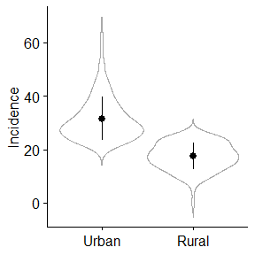

```r
library(ggpubr)
library(dplyr)
p = ggerrorplot(bc.data[[1]], x = "SSHID", y = "Incidence",
            desc_stat = "mean_sd", color = "black",
            add = "violin", add.params = list(color = "darkgray")
            )

p + scale_x_discrete(labels=c("1" = "Urban", "2" = "Rural")) +
  theme(axis.title.x = element_blank())
```

```r
bc.data[[1]] %>%
  group_by(SSHID) %>%
  summarise_at(vars(Incidence),
               list(name = mean))
```

```
## # A tibble: 2 x 2
##   SSHID  name
##   <int> <dbl>
## 1     1  31.6
## 2     2  17.5
```

### Running the Sandwich model

The Sandwich model-based mapping is performed using the `sandwich.model` function, which outputs the mean value of the sampling attribute and its standard error for each reporting unit.

```r
# Perform the SSH based spatial interpolation
bc.sw <- sandwich.model(object=bc.data, sampling.attr="Incidence", type="txt",
                        ssh.id.col="SSHID", ssh.weights=list(c(1,2), c("W1","W2")))
head(bc.sw)
```

```
##   GBCODE        W1        W2     mean        se  df
## 1 110100 0.8736000 0.1264000 29.78768 0.7965111 240
## 2 110112 0.6115000 0.3885000 26.11263 0.6894776 240
## 3 110113 0.5378000 0.4622000 25.07924 0.6604525 240
## 4 110221 0.5245597 0.4754403 24.89360 0.6552986 240
## 5 110224 0.5245597 0.4754403 24.89360 0.6552986 240
## 6 110226 0.5245597 0.4754403 24.89360 0.6552986 240
```

The confidence interval for the population mean in each reporting unit is computed using the `sandwich.ci` function. Here, we show an example of constructing a 95% confidence interval.

```r
# Calculate the confidence intervals of the interpolation estimates
bc.sw.ci <- sandwich.ci(object=bc.sw, level=.95)
head(bc.sw.ci)
```

```
##   GBCODE        W1        W2     mean        se  df   ci.low    ci.up
## 1 110100 0.8736000 0.1264000 29.78768 0.7965111 240 28.21863 31.35672
## 2 110112 0.6115000 0.3885000 26.11263 0.6894776 240 24.75443 27.47083
## 3 110113 0.5378000 0.4622000 25.07924 0.6604525 240 23.77822 26.38027
## 4 110221 0.5245597 0.4754403 24.89360 0.6552986 240 23.60272 26.18447
## 5 110224 0.5245597 0.4754403 24.89360 0.6552986 240 23.60272 26.18447
## 6 110226 0.5245597 0.4754403 24.89360 0.6552986 240 23.60272 26.18447
```

### Model validation

To evaluate the overall accuracy of the Sandwich model, a *k*-fold cross validation can be performed using the `sandwich.cv` function. A diagnostic statistic called root mean square error (RMSE) will be calculated. Here, we present the result of a 5-fold cross validation.

```r
# Perform k-fold cross validation
bc.cv <- sandwich.cv(object=bc.data, sampling.attr="Incidence", k=5, type="txt",
                     ssh.id.col="SSHID", reporting.id.col="GBCODE",
                     ssh.weights=list(c(1,2), c("W1","W2")))
bc.cv
```

```
## [1] 8.687603
```

[^1]: Wang, J. F., Haining, R., Liu, T. J., Li, L. F., & Jiang, C. S. (2013). Sandwich estimation for multi-unit reporting on a stratified heterogeneous surface. *Environment and Planning A*, 45(10), 2515-2534.
[^2]: Wang, J. F., Zhang, T. L., & Fu, B. J. (2016). A measure of spatial stratified heterogeneity. *Ecological Indicators*, 67, 250-256.
[^3]: Wang, J. F., Li, X. H., Christakos, G., Liao, Y. L., Zhang, T., Gu, X., & Zheng, X. Y. (2010). Geographical detectors-based health risk assessment and its application in the neural tube defects study of the Heshun Region, China. *International Journal of Geographical Information Science*, 24(1), 107-127.